# tips 데이터를 이용한 선형 모델링과 예측

202116927 오준석

2024-05-12

```r
library(scatterplot3d)
library(dplyr)
tips <- read.csv("tips.csv")
tips
```

```
##     total_bill   tip    sex smoker  day   time size
## 1        16.99  1.01 Female     No  Sun Dinner    2
## 2        10.34  1.66   Male     No  Sun Dinner    3
## 3        21.01  3.50   Male     No  Sun Dinner    3
## 4        23.68  3.31   Male     No  Sun Dinner    2
## 5        24.59  3.61 Female     No  Sun Dinner    4
## 6        25.29  4.71   Male     No  Sun Dinner    4
## 7         8.77  2.00   Male     No  Sun Dinner    2
## 8        26.88  3.12   Male     No  Sun Dinner    4
## 9        15.04  1.96   Male     No  Sun Dinner    2
## 10       14.78  3.23   Male     No  Sun Dinner    2
## 11       10.27  1.71   Male     No  Sun Dinner    2
## 12       35.26  5.00 Female     No  Sun Dinner    4
## 13       15.42  1.57   Male     No  Sun Dinner    2
## 14       18.43  3.00   Male     No  Sun Dinner    4
```

[output cut: 230 more lines]

tips 데이터에 여러 변수가 포함되어 있으며, tip의 값을 구하기 위해 응답 변수는 tip으로 설정함.

size를 설명 변수로 하는 그래프를 그림

```r
m=lm(tip~size, data=tips)
summary(m)
```

```
##
## Call:
## lm(formula = tip ~ size, data = tips)
##
## Residuals:
##     Min      1Q  Median      3Q     Max
## -2.7282 -0.8478 -0.0928  0.5872  6.6954
##
## Coefficients:
##             Estimate Std. Error t value Pr(>|t|)
## (Intercept)  1.16913    0.22342   5.233 3.61e-07 ***
## size         0.71182    0.08156   8.728 4.30e-16 ***
## ---
## Signif. codes:  0 '***' 0.001 '**' 0.01 '*' 0.05 '.' 0.1 ' ' 1
##
## Residual standard error: 1.209 on 242 degrees of freedom
## Multiple R-squared:  0.2394, Adjusted R-squared:  0.2363
## F-statistic: 76.18 on 1 and 242 DF,  p-value: 4.301e-16
```

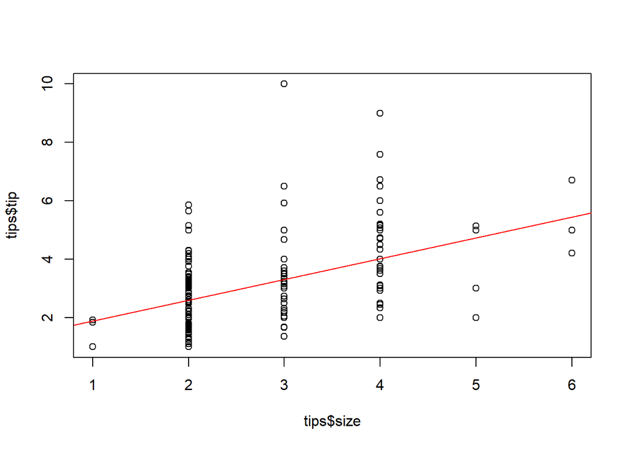

```r
plot(tips$size, tips$tip)
abline(m, col="red")
```

```r
deviance(m)/length(tips)
```

```
## [1] 50.54778
```

p값이 매우 작으므로 두 변수 간의 관계가 있다는 것을 알 수 있음

다음으로 total_bill을 설명 변수로 하는 그래프를 그리면

```r
m=lm(tip~total_bill, data=tips)
summary(m)
```

```
##
## Call:
## lm(formula = tip ~ total_bill, data = tips)
##
## Residuals:
##     Min      1Q  Median      3Q     Max
## -3.1982 -0.5652 -0.0974  0.4863  3.7434
##
## Coefficients:
##             Estimate Std. Error t value Pr(>|t|)
## (Intercept) 0.920270   0.159735   5.761 2.53e-08 ***
## total_bill  0.105025   0.007365  14.260  < 2e-16 ***
## ---
## Signif. codes:  0 '***' 0.001 '**' 0.01 '*' 0.05 '.' 0.1 ' ' 1
##
## Residual standard error: 1.022 on 242 degrees of freedom
## Multiple R-squared:  0.4566, Adjusted R-squared:  0.4544
## F-statistic: 203.4 on 1 and 242 DF,  p-value: < 2.2e-16
```

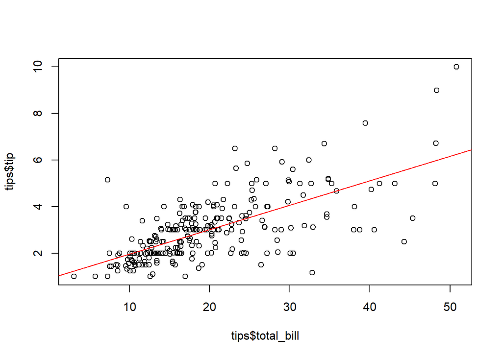

```r
plot(tips$total_bill, tips$tip)
abline(m, col="red")
```

```r
deviance(m)/length(tips)
```

```
## [1] 36.11268
```

이때 역시 p값이 매우 작음. 이를 통해 tip은 total_bill과 size 모두와 관련이 있다고 볼 수 있음.

세 개의 변수를 모두 이용한 3차원 그래프를 그려보면

```r
s=scatterplot3d(tips$total_bill, tips$size, tips$tip, type="h", pch=20)
m=lm(tip~total_bill++size, data=tips)
summary(m)
```

```
##
## Call:
## lm(formula = tip ~ total_bill + +size, data = tips)
##
## Residuals:
##     Min      1Q  Median      3Q     Max
## -2.9279 -0.5547 -0.0852  0.5095  4.0425
##
## Coefficients:
##             Estimate Std. Error t value Pr(>|t|)
## (Intercept) 0.668945   0.193609   3.455  0.00065 ***
## total_bill  0.092713   0.009115  10.172  < 2e-16 ***
## size        0.192598   0.085315   2.258  0.02487 *
## ---
## Signif. codes:  0 '***' 0.001 '**' 0.01 '*' 0.05 '.' 0.1 ' ' 1
##
## Residual standard error: 1.014 on 241 degrees of freedom
## Multiple R-squared:  0.4679, Adjusted R-squared:  0.4635
## F-statistic: 105.9 on 2 and 241 DF,  p-value: < 2.2e-16
```

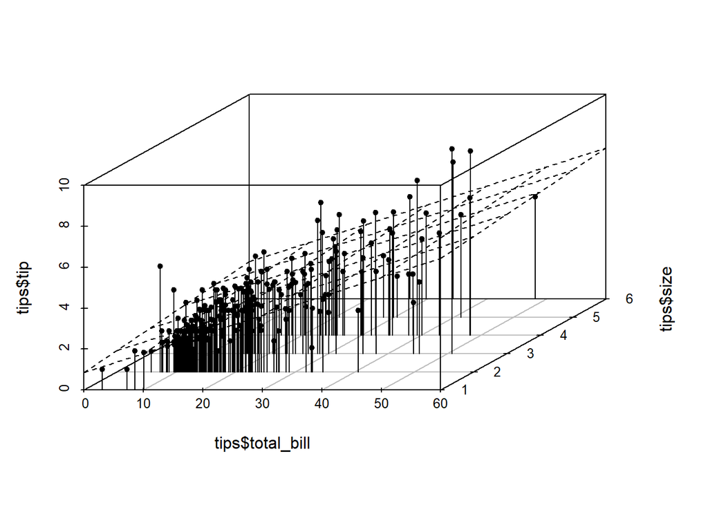

```r
s$plane3d(m)
```

```r
deviance(m)/length(tips)
```

```
## [1] 35.36483
```

앞선 과정을 통해 tip은 total_bill과 size와 연관이 있고 total_bill과 size를 모두 설명 변수로 하였을 때의 MSE가 가장 작음을 알 수 있었음.

tips 데이터에는 위의 변수 외에도 sex, smoker, day, time의 변수가 존재함. total_bill과 size를 모두 설명 변수로 하여 sex에 따른 MSE를 알아보면

```r
m=lm(tip~total_bill+size, data=tips%>%filter(sex=="Female"))
summary(m)
```

```
##
## Call:
## lm(formula = tip ~ total_bill + size, data = tips %>% filter(sex ==
##     "Female"))
##
## Residuals:
##      Min       1Q   Median       3Q      Max
## -2.54806 -0.44053 -0.07266  0.42220  2.72678
##
## Coefficients:
##             Estimate Std. Error t value Pr(>|t|)
## (Intercept)  0.76669    0.26114   2.936  0.00429 **
## total_bill   0.07904    0.01485   5.324 8.33e-07 ***
## size         0.26004    0.12681   2.051  0.04343 *
## ---
## Signif. codes:  0 '***' 0.001 '**' 0.01 '*' 0.05 '.' 0.1 ' ' 1
##
## Residual standard error: 0.8363 on 84 degrees of freedom
## Multiple R-squared:  0.4919, Adjusted R-squared:  0.4798
## F-statistic: 40.66 on 2 and 84 DF,  p-value: 4.458e-13
```

```r
deviance(m)/length(tips[tips$sex=="Female", ])
```

```
## [1] 8.392083
```

```r
m=lm(tip~total_bill+size, data=tips%>%filter(sex=="Male"))
summary(m)
```

```
##
## Call:
## lm(formula = tip ~ total_bill + size, data = tips %>% filter(sex ==
##     "Male"))
##
## Residuals:
##     Min      1Q  Median      3Q     Max
## -2.9939 -0.6855 -0.1206  0.6168  3.9065
##
## Coefficients:
##             Estimate Std. Error t value Pr(>|t|)
## (Intercept)  0.61104    0.26893   2.272   0.0245 *
## total_bill   0.09781    0.01163   8.410  2.6e-14 ***
## size         0.17092    0.11249   1.519   0.1307
## ---
## Signif. codes:  0 '***' 0.001 '**' 0.01 '*' 0.05 '.' 0.1 ' ' 1
##
## Residual standard error: 1.105 on 154 degrees of freedom
## Multiple R-squared:  0.4567, Adjusted R-squared:  0.4497
## F-statistic: 64.73 on 2 and 154 DF,  p-value: < 2.2e-16
```

```r
deviance(m)/length(tips[tips$sex=="male", ])
```

```
## [1] 26.84749
```

이를 통해 여성의 MSE가 낮음을 알 수 있음 같은 방식으로 나머지 변수에 따른 MSE를 구하면

```r
m=lm(tip~total_bill+size, data=tips%>%filter(smoker=="Yes"))
summary(m)
```

```
##
## Call:
## lm(formula = tip ~ total_bill + size, data = tips %>% filter(smoker ==
##     "Yes"))
##
## Residuals:
##     Min      1Q  Median      3Q     Max
## -2.5121 -0.7586 -0.2114  0.5300  5.0278
##
## Coefficients:
##             Estimate Std. Error t value Pr(>|t|)
## (Intercept)  1.29556    0.41014   3.159 0.002157 **
## total_bill   0.06182    0.01536   4.024 0.000119 ***
## size         0.17854    0.18628   0.958 0.340427
## ---
## Signif. codes:  0 '***' 0.001 '**' 0.01 '*' 0.05 '.' 0.1 ' ' 1
##
## Residual standard error: 1.23 on 90 degrees of freedom
## Multiple R-squared:  0.2461, Adjusted R-squared:  0.2293
## F-statistic: 14.69 on 2 and 90 DF,  p-value: 3.023e-06
```

```r
deviance(m)/length(tips[tips$smoker=="Yes", ])
```

```
## [1] 19.46245
```

```r
m=lm(tip~total_bill+size, data=tips%>%filter(smoker=="No"))
summary(m)
```

```
##
## Call:
## lm(formula = tip ~ total_bill + size, data = tips %>% filter(smoker ==
##     "No"))
##
## Residuals:
##      Min       1Q   Median       3Q      Max
## -2.43498 -0.36056 -0.05737  0.43706  2.14286
##
## Coefficients:
##             Estimate Std. Error t value Pr(>|t|)
## (Intercept)  0.32159    0.18644   1.725   0.0866 .
## total_bill   0.13402    0.01075  12.467   <2e-16 ***
## size         0.03697    0.08718   0.424   0.6721
## ---
## Signif. codes:  0 '***' 0.001 '**' 0.01 '*' 0.05 '.' 0.1 ' ' 1
##
## Residual standard error: 0.7887 on 148 degrees of freedom
## Multiple R-squared:  0.6764, Adjusted R-squared:  0.672
## F-statistic: 154.7 on 2 and 148 DF,  p-value: < 2.2e-16
```

```r
deviance(m)/length(tips[tips$smoker=="No", ])
```

```
## [1] 13.15285
```

흡연 여부 : 비흡연자의 MSE가 낮음

```r
m=lm(tip~total_bill+size, data=tips%>%filter(day=="Thur"))
summary(m)
```

```
##
## Call:
## lm(formula = tip ~ total_bill + size, data = tips %>% filter(day ==
##     "Thur"))
##
## Residuals:
##     Min      1Q  Median      3Q     Max
## -1.6145 -0.4148 -0.1145  0.3755  2.3777
##
## Coefficients:
##             Estimate Std. Error t value Pr(>|t|)
## (Intercept)  0.37507    0.24572   1.526    0.132
## total_bill   0.11107    0.01643   6.760 6.87e-09 ***
## size         0.17638    0.12151   1.452    0.152
## ---
## Signif. codes:  0 '***' 0.001 '**' 0.01 '*' 0.05 '.' 0.1 ' ' 1
##
## Residual standard error: 0.7225 on 59 degrees of freedom
## Multiple R-squared:  0.6717, Adjusted R-squared:  0.6606
## F-statistic: 60.36 on 2 and 59 DF,  p-value: 5.357e-15
```

```r
deviance(m)/length(tips[tips$day=="Thur", ])
```

```
## [1] 4.400137
```

```r
m=lm(tip~total_bill+size, data=tips%>%filter(day=="Fri"))
summary(m)
```

```
##
## Call:
## lm(formula = tip ~ total_bill + size, data = tips %>% filter(day ==
##     "Fri"))
##
## Residuals:
##      Min       1Q   Median       3Q      Max
## -0.85418 -0.42127 -0.06172  0.31047  1.64419
##
## Coefficients:
##             Estimate Std. Error t value Pr(>|t|)
## (Intercept) 1.106899   0.624472   1.773  0.09534 .
## total_bill  0.094733   0.025143   3.768  0.00168 **
## size        0.001436   0.368088   0.004  0.99693
## ---
## Signif. codes:  0 '***' 0.001 '**' 0.01 '*' 0.05 '.' 0.1 ' ' 1
##
## Residual standard error: 0.6875 on 16 degrees of freedom
## Multiple R-squared:  0.5959, Adjusted R-squared:  0.5454
## F-statistic:  11.8 on 2 and 16 DF,  p-value: 0.0007113
```

```r
deviance(m)/length(tips[tips$day=="Fri", ])
```

```
## [1] 1.080246
```

```r
m=lm(tip~total_bill+size, data=tips%>%filter(day=="Sat"))
summary(m)
```

```
##
## Call:
## lm(formula = tip ~ total_bill + size, data = tips %>% filter(day ==
##     "Sat"))
##
## Residuals:
##     Min      1Q  Median      3Q     Max
## -3.3689 -0.4843 -0.0196  0.6011  3.3487
##
## Coefficients:
##             Estimate Std. Error t value Pr(>|t|)
## (Intercept)  0.49309    0.41220   1.196    0.235
## total_bill   0.12019    0.01643   7.314 1.41e-10 ***
## size         0.01718    0.19016   0.090    0.928
## ---
## Signif. codes:  0 '***' 0.001 '**' 0.01 '*' 0.05 '.' 0.1 ' ' 1
##
## Residual standard error: 1.173 on 84 degrees of freedom
## Multiple R-squared:  0.4951, Adjusted R-squared:  0.4831
## F-statistic: 41.19 on 2 and 84 DF,  p-value: 3.411e-13
```

```r
deviance(m)/length(tips[tips$day=="Sat", ])
```

```
## [1] 16.49988
```

```r
m=lm(tip~total_bill+size, data=tips%>%filter(day=="Sun"))
summary(m)
```

```
##
## Call:
## lm(formula = tip ~ total_bill + size, data = tips %>% filter(day ==
##     "Sun"))
##
## Residuals:
##      Min       1Q   Median       3Q      Max
## -2.39019 -0.70910 -0.04782  0.58423  2.87990
##
## Coefficients:
##             Estimate Std. Error t value Pr(>|t|)
## (Intercept)  1.27613    0.38496   3.315  0.00143 **
## total_bill   0.05100    0.01627   3.135  0.00247 **
## size         0.31210    0.14263   2.188  0.03186 *
## ---
## Signif. codes:  0 '***' 0.001 '**' 0.01 '*' 0.05 '.' 0.1 ' ' 1
##
## Residual standard error: 1.049 on 73 degrees of freedom
## Multiple R-squared:  0.2978, Adjusted R-squared:  0.2786
## F-statistic: 15.48 on 2 and 73 DF,  p-value: 2.486e-06
```

```r
deviance(m)/length(tips[tips$day=="Sun", ])
```

```
## [1] 11.4727
```

요일별 : 금요일의 MSE가 가장 낮음

```r
m=lm(tip~total_bill+size, data=tips%>%filter(time=="Lunch"))
summary(m)
```

```
##
## Call:
## lm(formula = tip ~ total_bill + size, data = tips %>% filter(time ==
##     "Lunch"))
##
## Residuals:
##     Min      1Q  Median      3Q     Max
## -1.6336 -0.4462 -0.1121  0.3764  2.3760
##
## Coefficients:
##             Estimate Std. Error t value Pr(>|t|)
## (Intercept)   0.4289     0.2311   1.856    0.068 .
## total_bill    0.1087     0.0160   6.793 4.02e-09 ***
## size          0.1795     0.1187   1.512    0.135
## ---
## Signif. codes:  0 '***' 0.001 '**' 0.01 '*' 0.05 '.' 0.1 ' ' 1
##
## Residual standard error: 0.7129 on 65 degrees of freedom
## Multiple R-squared:  0.6606, Adjusted R-squared:  0.6502
## F-statistic: 63.27 on 2 and 65 DF,  p-value: 5.576e-16
```

```r
deviance(m)/length(tips[tips$time=="Lunch", ])
```

```
## [1] 4.719072
```

```r
m=lm(tip~total_bill+size, data=tips%>%filter(time=="Dinner"))
summary(m)
```

```
##
## Call:
## lm(formula = tip ~ total_bill + size, data = tips %>% filter(time ==
##     "Dinner"))
##
## Residuals:
##     Min      1Q  Median      3Q     Max
## -2.9034 -0.7088 -0.0563  0.5647  4.1384
##
## Coefficients:
##             Estimate Std. Error t value Pr(>|t|)
## (Intercept)  0.77811    0.26533   2.933  0.00382 **
## total_bill   0.08979    0.01106   8.120 8.42e-14 ***
## size         0.17382    0.11106   1.565  0.11937
## ---
## Signif. codes:  0 '***' 0.001 '**' 0.01 '*' 0.05 '.' 0.1 ' ' 1
##
## Residual standard error: 1.111 on 173 degrees of freedom
## Multiple R-squared:  0.4089, Adjusted R-squared:  0.4021
## F-statistic: 59.84 on 2 and 173 DF,  p-value: < 2.2e-16
```

```r
deviance(m)/length(tips[tips$time=="Dinner", ])
```

```
## [1] 30.48311
```

시간대 : 점심의 MSE가 더 낮음